# Tarea Nº5

Alejandro Calderón - Macarena Riddle

4/12/2018

**Pregtuna 2**

*Pregtuna 2.1* *Descargue el precio de las acciones de Microsoft (“MSFT”) y Apple (“AAPL”) desde Enero del 2000 hasta Agosto del 2018 con periodicidad mensual*

```r
MSFT_price <- tq_get("MSFT",
                     get = "stock.prices",
                     from = "1999-11-01",
                     to = "2018-09-05",
                     periodicity = "monthly")

MSFT_quantmod <- getSymbols("MSFT",
                            src = "yahoo",
                            from = "1999-11-01",
                            to = "2018-09-05",
                            periodicity = "monthly")

AAPL_price <- tq_get("AAPL",
                     get = "stock.prices",
                     from = "1999-11-01",
                     to = "2018-09-05",
                     periodicity = "monthly")

AAPL_quantmod <- getSymbols("AAPL",
                            src = "yahoo",
                            from = "1999-11-01",
                            to = "2018-09-05",
                            periodicity = "monthly")

MSFT_quantmod <- as.data.frame(MSFT) %>%
  as.tibble() %>%
  mutate(date = index(MSFT)) %>%
  rename("open" = "MSFT.Open", "high" = "MSFT.High",
         "low" = "MSFT.Low" , "close"= "MSFT.Close",
         "volume" = "MSFT.Volume", "adjusted" = "MSFT.Adjusted")
x <- length(MSFT_price$adjusted)

AAPL_quantmod <- as.data.frame(AAPL) %>%
  as.tibble() %>%
  mutate(date = index(AAPL)) %>%
  rename("open" = "AAPL.Open", "high" = "AAPL.High",
         "low" = "AAPL.Low" , "close"= "AAPL.Close",
         "volume" = "AAPL.Volume", "adjusted" = "AAPL.Adjusted")
y <- length(AAPL_price$adjusted)
```

*Letra A*

*Calcular los retornos*

```r
for (i in 1:x) {
  MSFT_price[i+1,8] = log(MSFT_price[i+1,7] / MSFT_price[i,7])
  if(i <= 2) {MSFT_price[i+1,9] = MSFT_price[i+1,8] + MSFT_price[i,8]}
  else{MSFT_price[i+1,9] = MSFT_price[i,9] + MSFT_price[i+1,8]}

}

for(i in 1:y){
  AAPL_price[i+1,8] = log(AAPL_price[i+1,7]/AAPL_price[i,7])
  if(i <= 2){AAPL_price[i+1,9] = AAPL_price[i+1,8] + AAPL_price[i,8]}
  else{AAPL_price[i+1,9] = AAPL_price[i,9] + AAPL_price[i+1,8]}
}

MSFT_price = MSFT_price %>% rename(retornos_activos = "adjusted.1")
MSFT_price = MSFT_price %>% rename(retornos_acum_activos = "adjusted.1.1")

MSFT_retorno <- MSFT_price[3:226,]
r1 <- length(MSFT_retorno$retornos_activos)
sum(MSFT_retorno$retornos_activos)
```

```
## [1] 0.9670086
```

```r
AAPL_price = AAPL_price %>% rename(retornos_activos = "adjusted.1")
AAPL_price = AAPL_price %>% rename(retornos_acum_activos = "adjusted.1.1")

AAPL_retorno <- AAPL_price[3:226,]
r2 <- length(AAPL_price$retornos_activos)
sum(AAPL_price$retornos_activos)
```

```
## [1] NA
```

*Letra B*

*Graficar los retornos y retornos acumulados*

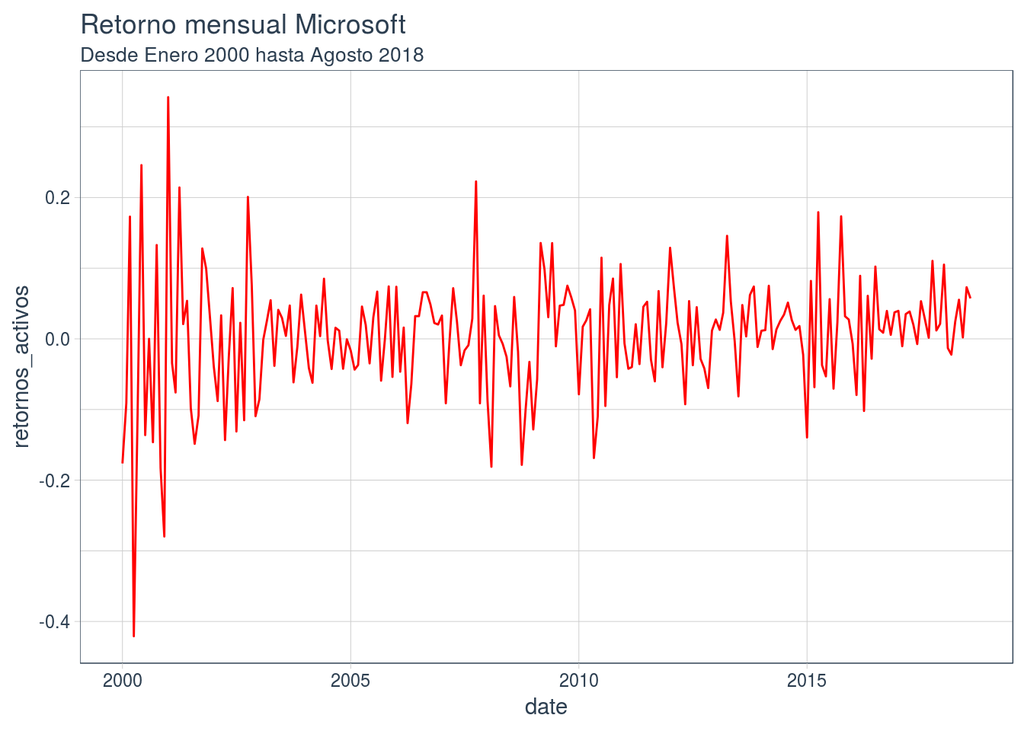

```r
#Gráficos Microsoft

ggplot(MSFT_retorno) + geom_line(aes(x=date, y=retornos_activos), color = "red") +
  labs(title = "Retorno mensual Microsoft", subtitle = "Desde Enero 2000 hasta Agosto 2018")+
  theme_tq() + scale_color_tq()
```

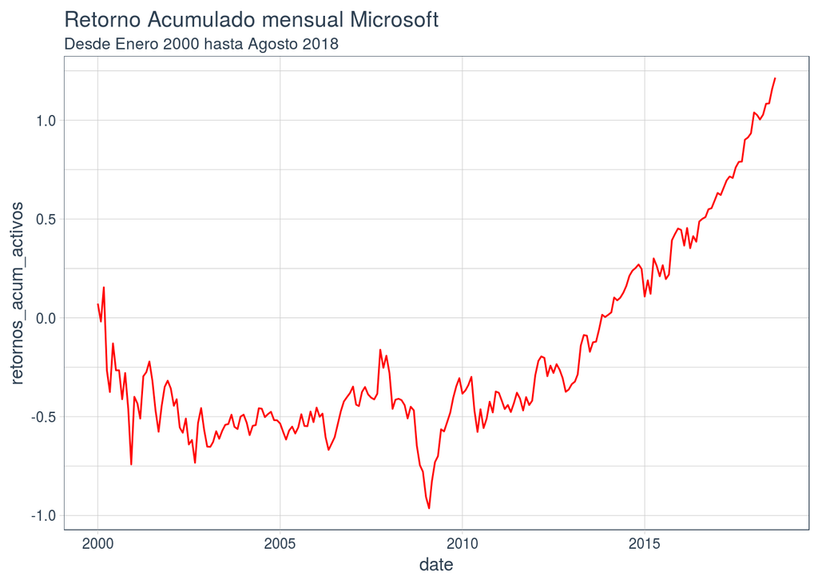

```r
ggplot(MSFT_retorno) + geom_line(aes(x=date, y=retornos_acum_activos), color = "red") +
  labs(title = "Retorno Acumulado mensual Microsoft", subtitle = "Desde Enero 2000 hasta Agosto 2018")+
  theme_tq() + scale_color_tq()
```

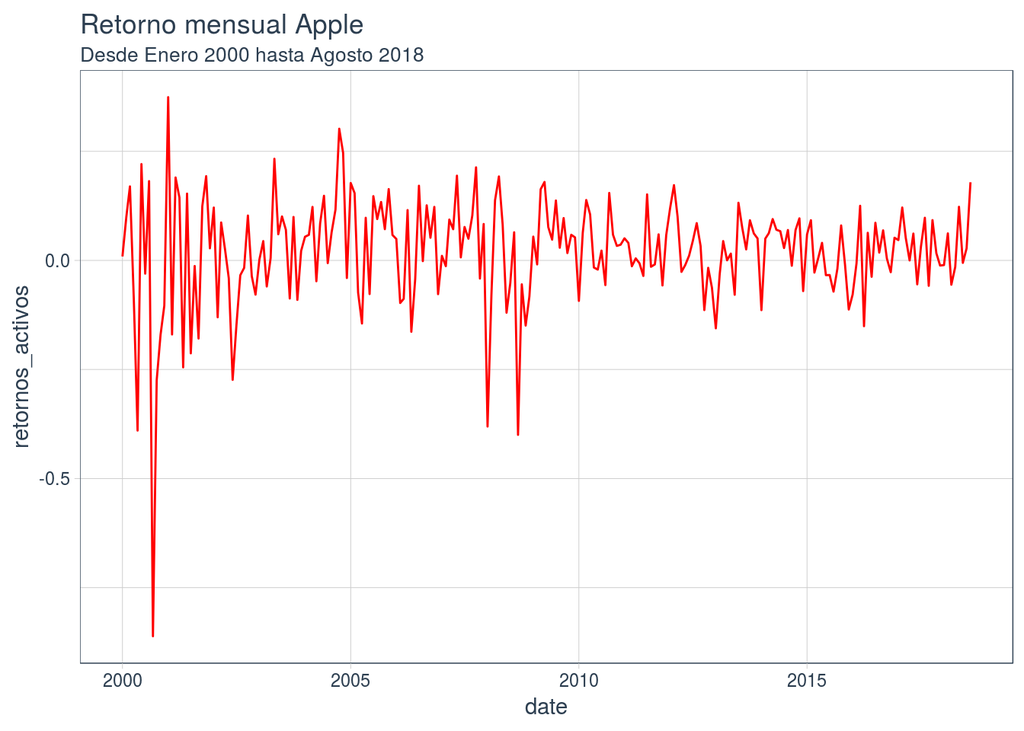

```r
#Gráficos Apple

ggplot(AAPL_retorno) + geom_line(aes(x=date, y=retornos_activos), color = "red") +
  labs(title = "Retorno mensual Apple", subtitle = "Desde Enero 2000 hasta Agosto 2018")+
  theme_tq() + scale_color_tq()
```

[figure not shown]

```r
ggplot(AAPL_retorno) + geom_line(aes(x=date, y=retornos_activos), color = "red") +
  labs(title = "Retorno Acumulado mensual Apple", subtitle = "Desde Enero 2000 hasta Agosto 2018")+
  theme_tq() + scale_color_tq()
```

*Letra C*

*Testear normalidad utilizando Jarque-Bera (JB)*

*Test para Microsoft*

```r
m1 <- sum(MSFT_retorno$retornos_activos)/r1
m2 <- sum((MSFT_retorno$retornos_activos - m1)^2)
m3 <- sum((MSFT_retorno$retornos_activos - m1)^3)
m4 <- sum((MSFT_retorno$retornos_activos - m1)^4)

asim1 <- (m3/m2^(3/2))^2 #calculo coeficiente de
asim2 <- (m4/m2^2)

JB_MSFT <- r1*asim1/6+(asim2-3)^2/24 #Test Jarque-Bera


chi_cuadrado_MSFT <- 1 - pchisq(JB_MSFT, df = 2) #Chi-cuadrado

#H0: retornos presentan normalidad
#H1: retornos no presentan normalidad

norm_MSFT = if(JB_MSFT > chi_cuadrado_MSFT){"Se rechaza la hipotesis nula"}else{"No se rechaza la hipotesis nula"}
norm_MSFT
```

```
## [1] "No se rechaza la hipotesis nula"
```

*Test para Apple*

```r
a1 <- sum(AAPL_retorno$retornos_activos)/r2
a2 <- sum((AAPL_retorno$retornos_activos - a1)^2)
a3 <- sum((AAPL_retorno$retornos_activos - a1)^3)
a4 <- sum((AAPL_retorno$retornos_activos - a1)^4)

asima1 <- (a3/a2^(3/2))^2
asima2 <- (a4/a2^2)

JB_AAPL <- r2*asima1/6+(asima2-3)^2/24

chi_cuadrado_AAPL <- 1 - pchisq(JB_AAPL, df = 2)

#H0: retornos presentan normalidad
#H1: retornos no presentan normalidad

norm_AAPL= if(JB_AAPL > chi_cuadrado_AAPL){"Se rechaza la hipotesis nula"}else{"No se rechaza la hipotesis nula"}
norm_AAPL
```

```
## [1] "Se rechaza la hipotesis nula"
```

**Pregunta 3**

Suponga que el modelo poblacional es el siguiente: y = β0 + β1x1 + β2x2 + u

Sin embargo, por ignorancia o falta de datos, se estima el modelo excluyendo x2, realizándose la siguiente regresión simple de y sólo sobre x1: y = β0 + β1x1 + v, donde v = β2x2 + u

Para responder (a) y (b) asuma x2 =0,8x1+e, dondex1 ∼N(20,1) y e∼N(0,1)

**Letra A**

*Calcule E(βˆ1) y var(βˆ1) para muestras de tamaños 50, 100, 500, 1000. ¿Existe sesgo?, ¿Desaparece el sesgo a medida que el tamaño de la muestra aumenta?*

*E(βˆ1) para muestras de tamaños 50, 100, 500, 1000*

```
##       X1       X2       X3       X4       X5       X6       X7       X8
## 3.266807 3.361860 3.283412 3.349777 2.502976 2.499524 2.499963 2.499738
```

*Var(βˆ1) para muestras de tamaños 50, 100, 500, 1000*

```
##           X1           X2           X3           X4           X5
## 0.0233267354 0.0090804310 0.0019405956 0.0009639818 0.0372850532
##           X6           X7           X8
## 0.0150215738 0.0031007197 0.0016975580
```

*Existe sesgo en el modelo que omite la variable, ya que el valor esperado de β_1 está lejos del valor poblacional, lo que indica la presencia de sesgo. Esto se debe a que la variable X_2 (la cual está siendo omitida) tiene correlación con X_1, provocando que el error se correlacione con la variable independiente del modelo y genere sesgo de inconsistencia, denominado sesgo de especificación.* *A medida que aumenta el tamaño de la muestra se puede notar que no desaparece el sesgo en el modelo que omite la variable, debido a que los valores de los estimadores oscilan indefinidamente aumentando y disminuyendo de manera intercalada. Por último, cabe destacar que la varianza va disminuyendo.*

**Letra B**

*Grafique la distribución de βˆ1 para tamaños de muestra n = 50, 100, 500, 1000*

*Modelo V.O.R = Modelo con Variable Omitida Relevante*

*Modelo Pob = Modelo Sin Variable Omitida*

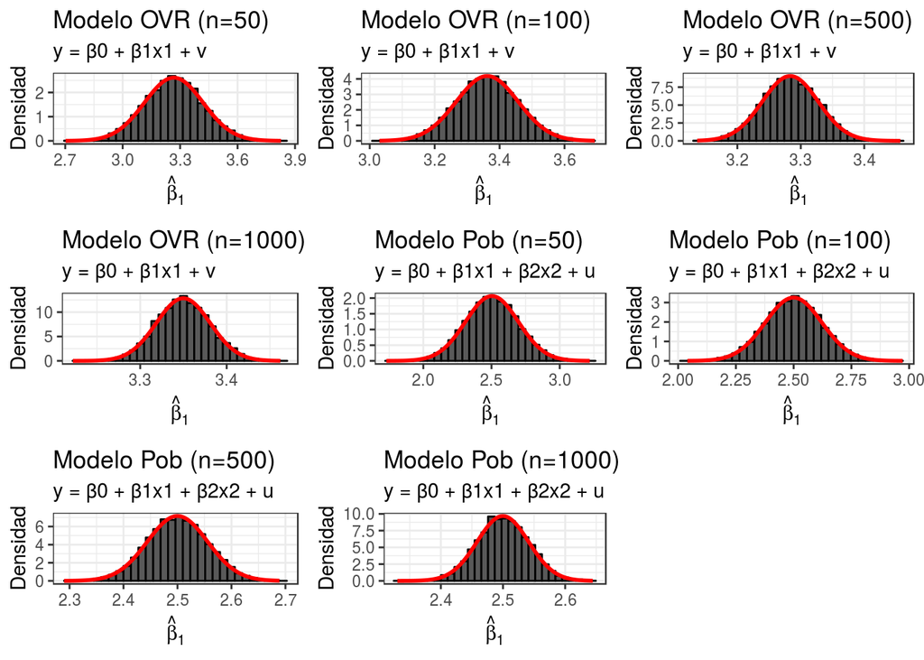

**Letra C**

*Si x2 ∼ U [0, 1], ¿Cómo cambian los resultados que obtuviste en (a) y (b)?*

*E(βˆ1) para muestras de tamaños 50, 100, 500, 1000*

```
##       X1       X2       X3       X4       X5       X6       X7       X8
## 2.522044 2.461283 2.495008 2.507052 2.500449 2.500658 2.500329 2.500213
```

*Var(βˆ1) para muestras de tamaños 50, 100, 500, 1000*

```
##           X1           X2           X3           X4           X5
## 0.0241325532 0.0094700495 0.0019400706 0.0009732684 0.0242301507
##           X6           X7           X8
## 0.0096418018 0.0019407267 0.0009742514
```

*Ahora que X_2 se distribuye de manera uniforme entre [0,1] los valores esperados de los estimadores se acercan al valor poblacional, eliminado el sesgo en los dos modelos.* *Los betas por otro lado tienen una distribución normal y las varianzas de los estimadores disminuyen al aumentar el tamaño de la muestra.* *Por otro lado, el modelo que no omite la variable posee un valor esperado de β_1 cercano al parámetro poblacional (2,5), por lo que no posee sesgo.*

*Grafique la distribución de βˆ1 para tamaños de muestra n = 50, 100, 500, 1000*

*Modelo V.O = Modelo con Variable Omitida*

*Modelo Pob = Modelo Sin Variable Omitida*

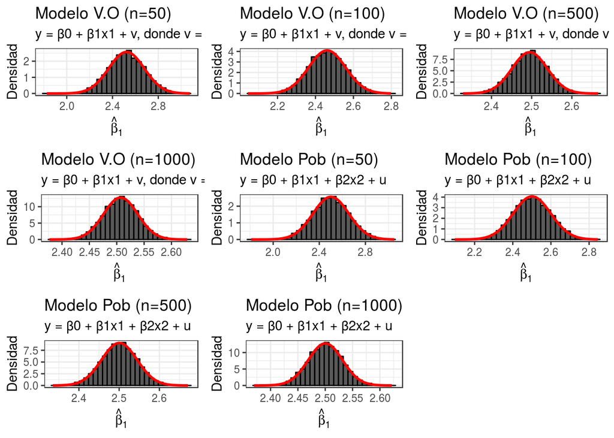